# Project 1 Final Paper

Melanie McCord

11/1/2021

# Introduction

## Background

Stress is a common aspect of modern lives that can cause negative health outcomes, such as anxiety, depression, insomnia, and a weakened immune system. If we can predict stress on social media, we can help understand the extent of the problem and perhaps gain insights on how to address it. For this specific project, the focus is on Reddit. Reddit is a social media platform where users post questions and can get advice. Importantly, Reddit data is concentrated on specific subreddits, divided by topic. This makes it easier to filter by specific topic and analyze the data from each specific topic. If we mine from stress-related subreddits, we can get a more detailed overview of the problem.

## Data Structure and Source

This dataset was collected by mining all posts from 10 subreddits between January 1, 2017 and November 19, 2018. Then, the data was annotated by human annotators as being either “stressed”, “non-stressed”, or “unclear”. The posts that were unclear as to whether or not they were stressed were discarded. For each post, the features are the text, the label, and some syntactic features, lexical features, and social media features, as well as the sentiment (how overly positive or negative the posts are).

For more information about the dataset, see this paper: [Dreaddit: A Reddit Dataset for Stress Analysis On Social Media](https://arxiv.org/abs/1911.00133).

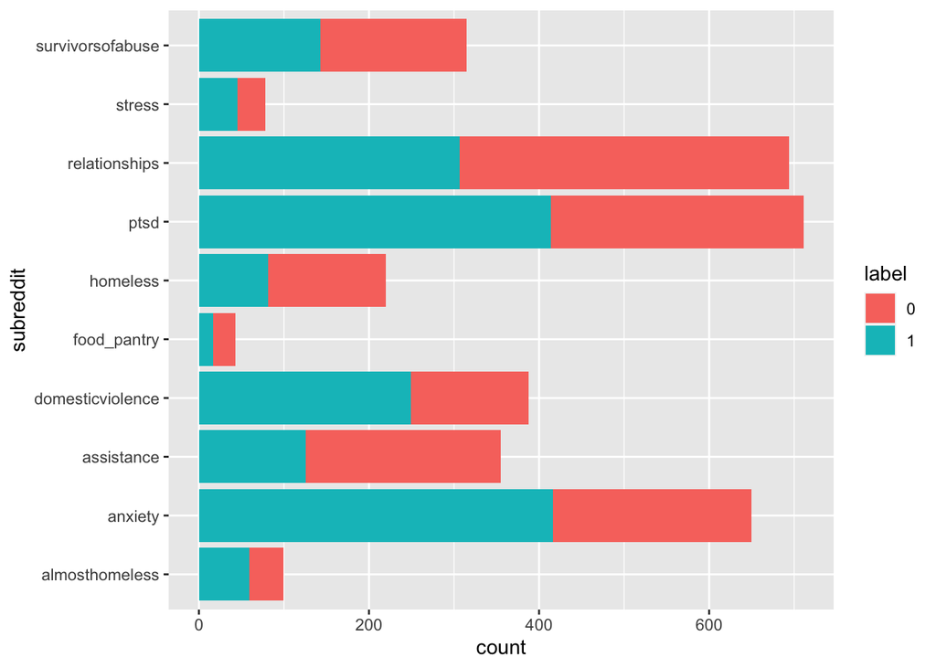

```r
reddit_stress_data <- read_feather("reddit_stress_data.feather")
reddit_stress_data %>%
  mutate(label = as.factor(label)) %>%
  ggplot(aes(y=subreddit)) + geom_bar(aes(fill = label), position="stack")
```

Clearly, the data is imbalanced between labels and subreddits. Therefore, classification algorithms may be biased in favor of misclassifying certain subreddits.

Additionally, punctuation, and capitalization causes issues. A computer considers “Don’t”, “don’t,” and “DONT” to be separate words. As part of my data wrangling, I needed to deal with this. Also, some words only appear in one post. For example, one post may ask about resources available in Louisiana, but no other post mentions Louisiana. We need a way to deal with these issues. It’s possible that rare words may indicate some information about the text, so we can’t just remove rare words. Therefore, I needed to identify and mark rare words.

This was the most complicated part of the project and it required me to make a definition of what a rare word is, which I decided to set as the number of occurrences = 15. The initial testing revealed that setting rare words at 15 resulted in the mean and standard deviation being significantly deviating, while for lower values the mean, median would always be very close to the mean. Then, I had to work with strings in order to match the rare words exactly. I decided to set the unknown token as “unk”.

Another minor issue that I ran into was joining the data together. Since “id” for example appears in both the dataset and in the posts, I needed to create a clear split. I did this by adding the abbreviation “text_” if the word appeared in the text. I also needed to join the bag of words model to the whole text, so that was part of my computing tasks.

# Results

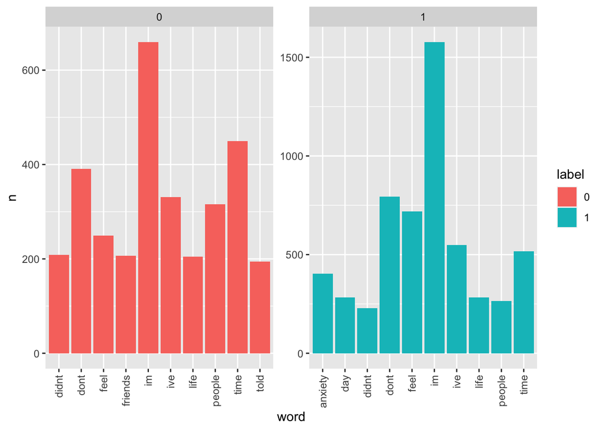

```r
words_tokenized <- reddit_stress_data %>%
  select(text, id) %>%
    unnest_tokens(word, text) %>%
    mutate(word = gsub('[[:punct:]]+','', word)) %>%
    mutate(word = gsub('\\<[[:digit:]]+\\>', '%d%', word)) %>%
    anti_join(stop_words, by = c("word" = "word")) %>%
  filter(word != "%d%")
GetTopNMostCommonWords <- function(df, num) {
  top_word_counts <- df %>%
    count(word) %>%
    arrange(desc(n))
  return (head(top_word_counts, num))
}
num <- 10
words_tokenized_by_label_counts <- reddit_stress_data %>%
  select(c("id", "text", "label", "subreddit")) %>%
  unnest_tokens(word, text) %>%
  mutate(word = gsub('[[:punct:]]+','', word)) %>%
  mutate(word = gsub('\\<[[:digit:]]+\\>', '%d%', word)) %>%
  anti_join(stop_words) %>%
  group_by(label) %>%
  count(word) %>%
  filter(word != "%d%") %>%
  arrange(label, desc(n))

words_tokenized_by_label_counts %>%
  top_n(num, n) %>%
  ungroup() %>%
  mutate(label = as.factor(label)) %>%
  arrange(label, desc(n)) %>%
  mutate(topic_r = row_number()) %>%
  ggplot(aes(word, n, fill = label)) +
  geom_col() +
  facet_wrap(~ label, scales = "free") + theme(axis.text.x=element_text(angle=90,hjust=1,vjust=0.5))
```

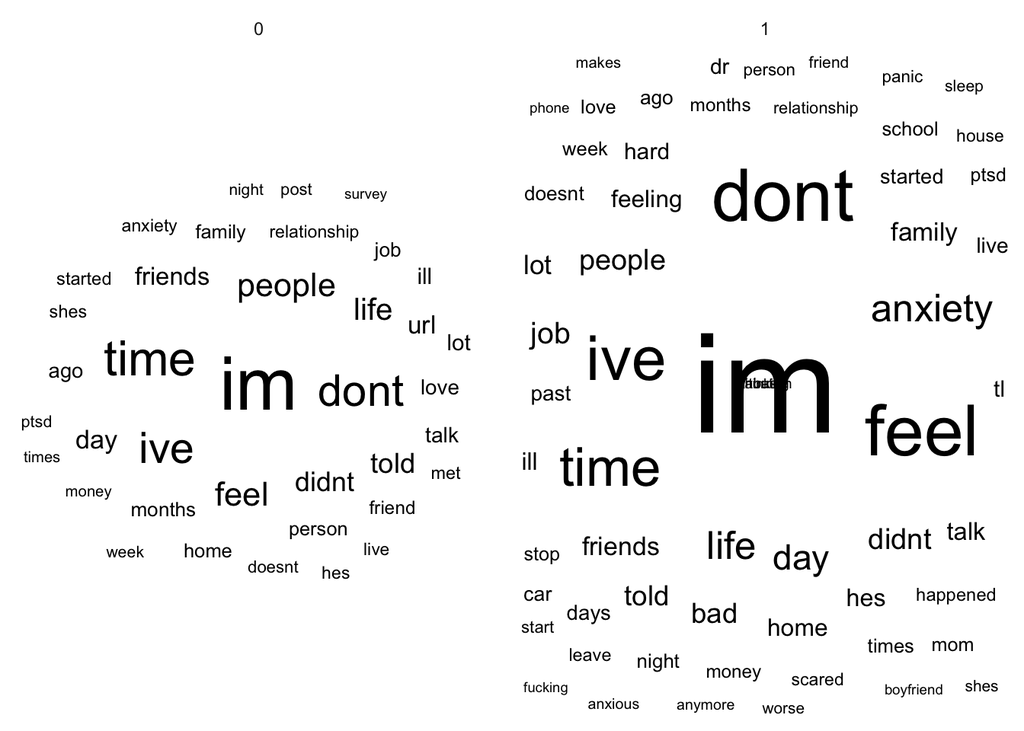

```r
words_tokenized_by_label_counts %>%
  arrange(desc(n)) %>%
  head(100) %>%
  ggplot(aes(label = word, size = n)) + geom_text_wordcloud(area_corr = TRUE) +
  scale_size_area(max_size = 24) + theme_minimal() + facet_wrap(~ label)
```